# PHOT 110: Introduction to programming

PHOT 110: Introduction to programming

LECTURE 08: Numerical Methods

Michaël Barbier

Version: April 30, 2026

# Numerical Methods

## Discretizing functions

- simplest: finite number of $x_i$ and $y_i = f(x_i)$ (with $i = 1, \dots , N$)
- Points $x_i$ can be regularly spaced
- Accuracy depends on:
  - how smooth the real function is
  - how close the points are taken But more points $\longrightarrow$ **more data**, **slower**

## Discretizing functions

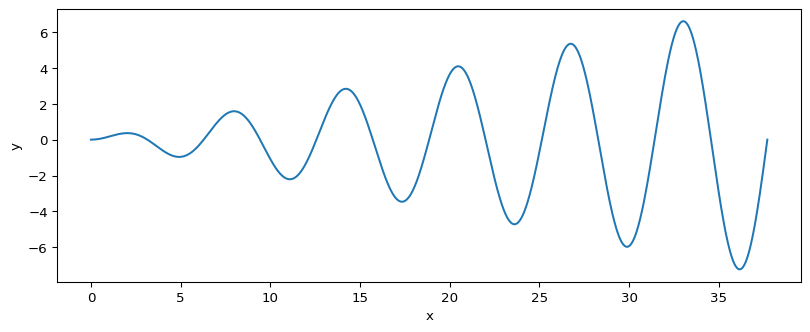

- The actual function is smooth

## Discretizing functions

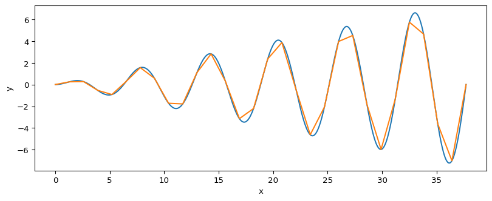

## Discretizing functions

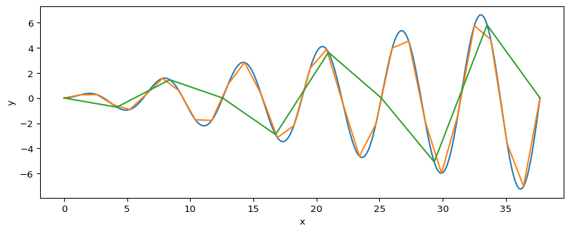

## Discretizing functions

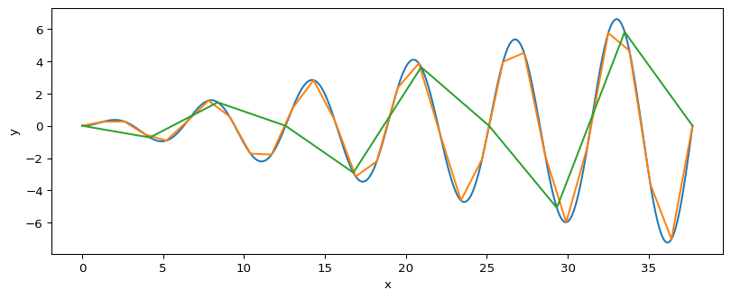

- How many points should be taken?
- More points take up more memory and require more calculations
- Choose interval length and stepsize according to function/problem

## Solving Equations: Root Finding

Example: polynomial equations in one variable:

$$\begin{aligned}
\textrm{Equation} \qquad&\qquad \textrm{(partial) solution}\\
4 x - 3 = 5 \qquad&\qquad x = 2\\
2 x^2 - x + 2 = 0 \qquad&\qquad x_\pm = \frac{1 \pm i\sqrt{15}}{4}\\
x^3 - 27 = 0 \qquad&\qquad (x - 3) (x^2 + 3x + 9)\\
x^5 - x^3 = 0 \qquad&\qquad x^3 (x^2 - 1)\\
x^3 - x^2 + x - 1 = 0 \qquad&\qquad \\
\end{aligned}$$

## Solving Transcendental Equations

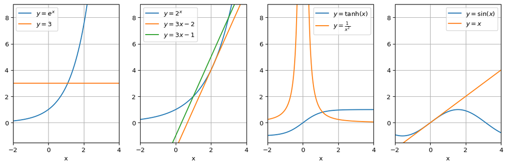

## Systems of equations

Examples of systems of equations:

$$\left\{
\begin{aligned}
4 x - y + 3 z = 5\\
12 x + y + z = -2\\
2 x - 1 z = 1\\
\end{aligned}\right.
\qquad\qquad
\left\{
\begin{aligned}
2 x^2 - x + 2 = 0\\
3 x^2 + x = 0\\
2 x - 1 = 0\\
\end{aligned}\right.
\qquad\qquad
\left\{
\begin{aligned}
\sin(x) + 5\cos(x) = 3\\
2\sin(x) - 2\cos(x) = 1\\
\end{aligned}\right.$$

- Independent variables $x$, $y$, $z$, or
- Polynomials in $x$, or
- Linear independent functions (e.g. $\sin(x)$, $\cos(x)$)

$$\begin{pmatrix}
4 & - 1 & 3\\
12 & 1 & 1\\
2 & 0 & -1\\
\end{pmatrix}
\begin{pmatrix}
x\\
y\\
z\\
\end{pmatrix}
=
\begin{pmatrix}
5\\
-2\\
1\\
\end{pmatrix},
\qquad
\begin{pmatrix}
2 & - 1 & 2\\
3 & 1 & 0\\
0 & 2 & -1\\
\end{pmatrix}
\begin{pmatrix}
x^2\\
x\\
1\\
\end{pmatrix}
=
\begin{pmatrix}
0\\
0\\
0\\
\end{pmatrix},\\
\qquad
\begin{pmatrix}
1 & 5\\
2 & -2\\
\end{pmatrix}
\begin{pmatrix}
\sin(x)\\
\cos(x)\\
\end{pmatrix}
=
\begin{pmatrix}
3\\
1\\
\end{pmatrix}$$

## Intermezzo: Matrix (addition)

Adding matrices is simple done by element-wise addition:

$$C = A + B = a_{ij} + b_{ij} =
\begin{pmatrix}
a_{11} & \color{blue}a_{12}\\
a_{21} & a_{22}\\
\end{pmatrix} +
\begin{pmatrix}
b_{11} & \color{blue}b_{12}\\
b_{21} & b_{22}\\
\end{pmatrix}
=
\begin{pmatrix}
a_{11} + b_{11} & \color{blue}a_{12} + b_{12}\\
a_{21} + b_{21} & a_{22} + b_{22}\\
\end{pmatrix}$$

## Intermezzo: Matrix Multiplication

A matrix product is defined multiplying the row elements of the first matrix with the column elements of the second and then summing over them. For the resulting element $c_{12}$ at row $i = 1$ and column $k = 2$ we colored the elements blue.

$$C = A\cdot B = \sum_{j} a_{ij} b_{jk} =
\begin{pmatrix}
\color{blue}a_{11} & \color{blue}a_{12}\\
a_{21} & a_{22}\\
\end{pmatrix}
\begin{pmatrix}
b_{11} & \color{blue}b_{12}\\
b_{21} & \color{blue}b_{22}\\
\end{pmatrix}
=
\begin{pmatrix}
a_{11} b_{11} + a_{12} b_{21} & \color{blue}a_{11} b_{12} + a_{12} b_{22}\\
a_{21} b_{11} + a_{22} b_{21} & a_{21} b_{12} + a_{22} b_{22}\\
\end{pmatrix}$$

## Eigenvalue equations

## Outlook

- Interpolation:
  - Curve fitting, smoothing, or interpolating data points
  - Piece-wise linear approximation
  - Polynomial (least squares) approximation
  - Applying splines
- Integration
  - Trapezoidal rule
  - Simpson’s rule
- 1D Finite difference schemes

# Interpolation

## Interpolation and curve fitting

- Limited “accurate” data points: values in between?
- Sufficient data but noisy: real curve?
- Question: Required to pass through the data points?

## When to use Interpolation ?

- Limited data: use interpolation
  - “Accurate” experimental data or,
  - computational hard tasks

## When to use curve fitting ?

- Use curve fitting for:
  - Noisy data: “smoothing” experimental data points
  - You have a known parameterized curve: optimize parameters Examples: $\,\,f(x) = a \sin(b\, x)$, $\,\,f (x) = \exp(-a x^2)$

## Piecewise linear interpolation

- Linear interpolation draws straight lines between the data points
- Formula to calculate the value of $x \in [x_i, x_{i+1}]$:
  $$f_i(x) = y_i + \frac{y_{i+1} - y_i}{x_{i+1} - x_i} \, (x - x_i)$$

## Piecewise linear interpolation

- Advantages: simple and fast to compute, always exists, robust.
- Disadvantage: the derivative is not continuous

## Global polynomials

- Higher polynomial order $n$
- Polynomial function of order $n$:
  $$f(x) = a_0 + a_1 x + a_2 x^2 + \dots + a_n x^n$$
- Polynomial function determined by column vector:
  $$\vec{a} = (a_0, a_1, a_2, \dots, a_n)^T$$
- Requirement to go through data points $(x_i, y_i)$, for every $i = 1 \dots N$:
  $$f(x_i) = a_0 + a_1 x_i + a_2 x_i^2 + \dots + a_n x_i^n = y_i$$

## Global polynomials: Matrix equation

$$f(x_i) = a_0 + a_1 x_i + a_2 x_i^2 + \dots + a_n x_i^n = y_i$$
System of equations $f(x_i) = y_i$ in matrix form $A\,\vec{a} = \vec{y}$:
$$\begin{pmatrix}
1 & x_1 & x_1^2 & \dots & x_1^n \\
1 & x_2 & x_2^2 & \dots & x_2^n \\
\vdots & \vdots & \vdots & & \vdots \\
1 & x_i & x_i^2 & \dots & x_i^n \\
\vdots & \vdots & \vdots & & \vdots \\
1 & x_N & x_N^2 & \dots & x_N^n \\
\end{pmatrix}
\begin{pmatrix}
a_0 \\ a_1 \\ a_2 \\ \vdots \\ a_n
\end{pmatrix}
=
\begin{pmatrix}
y_1 \\ y_2 \\ \vdots \\ y_i \\ \vdots \\ y_N
\end{pmatrix}$$

## Global polynomials: Exact fit

- $N$ rows/equations/points, $\,\,\,n+1$ columns/unknowns
- **Exact fit**: use polynomial order $n = N-1$: A
  $$\begin{pmatrix}
  1 & x_1 & x_1^2 & \dots & x_1^n \\
  1 & x_2 & x_2^2 & \dots & x_2^n \\
  \vdots & \vdots & \vdots & & \vdots \\
  1 & x_i & x_i^2 & \dots & x_i^n \\
  \vdots & \vdots & \vdots & & \vdots \\
  1 & x_N & x_N^2 & \dots & x_N^n \\
  \end{pmatrix}
  \begin{pmatrix}
  a_0 \\ a_1 \\ a_2 \\ \vdots \\ a_n
  \end{pmatrix}
  =
  \begin{pmatrix}
  y_1 \\ y_2 \\ \vdots \\ y_i \\ \vdots \\ y_N
  \end{pmatrix}$$

## Example quadratic fit

- Obtain unknowns $\,\,\vec{a} = (a_0, a_1, a_2)\,$ by $\,\vec{a} = A^{-1} \vec{y}$
  $$\begin{pmatrix}
  1 & x_1 & x_1^2 \\
  1 & x_2 & x_2^2 \\
  1 & x_3 & x_3^2 \\
  \end{pmatrix}
  \begin{pmatrix}
  a_0 \\ a_1 \\ a_2
  \end{pmatrix}
  =
  \begin{pmatrix}
  y_1 \\ y_2 \\ y_3
  \end{pmatrix}$$

## Global polynomials: Approximate curve fitting

- $N$ rows/equations/points, $\,\,\,n+1$ columns/unknowns
- **Approximate fit**: use polynomial order $n < N-1$
  $$\begin{pmatrix}
  1 & x_1 & x_1^2 & \dots & x_1^n \\
  1 & x_2 & x_2^2 & \dots & x_2^n \\
  \vdots & \vdots & \vdots & & \vdots \\
  1 & x_i & x_i^2 & \dots & x_i^n \\
  \vdots & \vdots & \vdots & & \vdots \\
  1 & x_N & x_N^2 & \dots & x_N^n \\
  \end{pmatrix}
  \begin{pmatrix}
  a_0 \\ a_1 \\ a_2 \\ \vdots \\ a_n
  \end{pmatrix}
  =
  \begin{pmatrix}
  y_1 \\ y_2 \\ \vdots \\ y_i \\ \vdots \\ y_N
  \end{pmatrix}$$

## Approximate polynomial fit: error

- $N$ rows/equations/points, $\,\,\,n+1$ columns/unknowns
- **Approximate fit**: use polynomial order $n < N-1$
- We cannot fit all points at the same time:
  $$A \vec{a} = \vec{y} \quad \Longrightarrow \quad A \vec{a} = \vec{y} + \vec{e}$$
- Errors $\vec{e} = (e_1, e_2, \dots, e_N)^T$ represent mismatch $y_i \longrightarrow y_i + e_i$
- Minimize the norm of unknown errors (least squares):
  $$\|\vec{e}\| = \vec{e}^T\cdot\vec{e} = \sqrt{\sum_{i = 1}^{N} e_i^2}$$

## Approximate polynomial fit: solution

- Minimize norm errors and solve resulting least-squares equation
  $$\|\vec{e}\| = \vec{e}^T\cdot\vec{e} = \sqrt{\sum_{i = 1}^{N} e_i^2} \quad\Longrightarrow\quad
  A^T A \vec{a} = A^T \vec{y}$$

## Example of splines: Cubic splines

- Splines: “local” fit, robust, but continuous differentiable

|  | **Natural** | **clamped** | **not-a-knot** |
| --- | --- | --- | --- |
| Boundary condition | $g''(x_0) = 0$ | $g'(x_0)$ fixed | $g'''(x_1) = 0$ |

# Integration

## Mid-point (Riemann) and Trapezium rules

[figure not shown]

$$I_\textrm{mid} = \sum_i f\left(\frac{x_{i-1} + x_{i}}{2}\right) h \quad
I_\textrm{trap} = \sum_i \frac{f(x_{i-1}) + f(x_{i})}{2} h$$

## Similar errors

[figure not shown]

$$E_\textrm{mid} \propto \frac{1}{24} h^2 \, (B-A) \qquad E_\textrm{trap} \propto \frac{1}{12} h^2 \, (B-A)$$

## Simpson’s rule

- Simpson’s rule extends trapezoidal
- Fit parabola to each segment

$$I_\textrm{Simpson} = \sum_i \frac{f(x_{i-1}) + 4f(x|_{i-1/2}) + f(x_{i})}{6} h$$

- Error is 4th order (instead of 2nd for trapezoidal rule):

$$E_\textrm{Simpson} \propto h^4 \, (B-A)$$

## Comments on integration schemes

- Data points can be spaced irregular: $h \longrightarrow h_i$
- Adaptive integration schemes can become more accurate where function is fluctuating stronger
- Example: Adaptive quadrature switches between Trapezoidal (rough) and Simpson (accurate)

# Differentiation

## 1D Finite difference schemes

[figure not shown]

- Formulas for the derivative $f_i' \equiv f'(x_i)$ at $x_i$ are:

| $f_i'$ backward | $f_i'$ forward | $f_i'$ central |
| --- | --- | --- |
| $\frac{f_i - f_{i-1}}{x_i - x_{i-1}} =\frac{f_i - f_{i-1}}{h}$ | $\frac{f_{i+1} - f_{i}}{x_{i+1} - x_{i}} = \frac{f_{i+1} - f_i}{h}$ | $\frac{f_{i+1} - f_{i-1}}{x_{i+1} - x_{i-1}} =\frac{f_{i+1} - f_{i-1}}{2h}$ |

## Best scheme?

- For on-the-fly calculations, only “old” values available: use backward scheme
- At boundaries: **forward** for left, **backward** for right boundary
- Other cases: central difference often has a smaller error

## Best scheme?

- For on-the-fly calculations, only “old” values available: use backward scheme
- At boundaries: **forward** for left, **backward** for right boundary
- Other cases: central difference often has a smaller error
  $$f_{i, \textrm{central}}' = f_i' + f_{i}'''\frac{h^2}{6} + \mathcal{O(h^4)}\quad \Longrightarrow \quad E_\textrm{central} \approx f_{i}'''\frac{h^2}{6}$$
  $$f_{i, \textrm{forward}}' = f_i' + f_{i}''\frac{h}{2} + \mathcal{O(h^2)}\quad \Longrightarrow \quad E_\textrm{forward} \approx f_{i}''\frac{h}{2}$$

## Example error for sine function

- Example: $f(x) = \sin(x)$, $f' = \cos(x)$, $f'' = -\sin(x)$
  - Error central difference mostly **smaller** than forward difference
  - **Central**(forward) difference performs **bad**(good) at inflection points of the function (curvature flips sign)

[output not shown]

[figure not shown]